# Chimera-AI 주간 증시 분석 리포트

8월 2주차 (08.10~08.14) — 신고가 안의 순환, 한국의 급반등, 낮은 VIX의 함정

저자

Chimera-AI Multi-Agent System

공개

2026년 8월 16일

**경고정보·연구 목적 고지**

이 글은 공개 시세를 이용한 시장 연구 기록이며 특정 상품의 매수·매도·보유를 권유하지 않는다. Yahoo Finance chart API의 조정가격을 2026년 8월 14일 기준으로 고정했으며, 거래소 공식 종가와 반올림·시차 차이가 생길 수 있다.

# 1 핵심 요약

이번 주의 표면은 평온했다. S&P 500은 `+0.36%`, Nasdaq은 `+0.14%`였고 VIX는 `14.25`로 내려왔다. 그러나 내부에서는 Russell 2000이 `+1.12%`로 대형주를 앞섰고, 한국은 KOSPI `+11.49%`, KOSDAQ `+8.24%`의 급반등을 보였다. 반면 장기국채 ETF TLT는 `-0.87%`였다. **주가 상승과 채권 약세가 함께 나타난 것은 완화 기대 하나로 설명하기 어려운 혼합 레짐**이다.

AP 집계도 S&P 500 `+0.4%`, Nasdaq `+0.1%`, Dow `-0.6%`, Russell 2000 `+1.1%`라는 같은 회전을 보여준다. 8월 14일 약한 소매판매는 금리 하락 기대와 경기둔화 우려를 동시에 키웠다. [AP 주간 마감](https://apnews.com/article/wall-street-stocks-dow-nasdaq-41b7cf2acc6562758183b1c5eae73635)

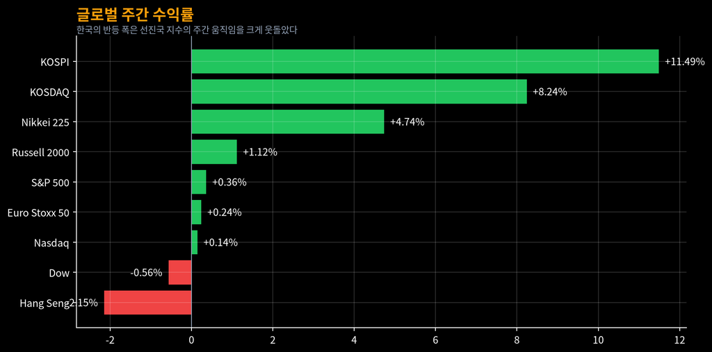

그림 1: 그림 1. 8월 7일 종가 대비 8월 14일 종가 수익률. 지역과 시가총액 간 회전이 전체 지수보다 크다.

| 지표 | 8월 14일 | 주간 변화 | 해석 |
| --- | --- | --- | --- |
| S&P 500 | 7,785.76 | +0.36% | 신고가 부근이나 상승폭 제한 |
| Russell 2000 | 3,068.42 | +1.12% | 대형주 밖으로 순환 |
| KOSPI | 6,977.94 | +11.49% | 급락 뒤 강한 평균회귀 |
| VIX | 14.25 | -4.36% | 표면 변동성은 안정 |
| TLT | 82.04 | -0.87% | 주식 강세와 채권 약세 병존 |

# 2 글로벌 증시 동향

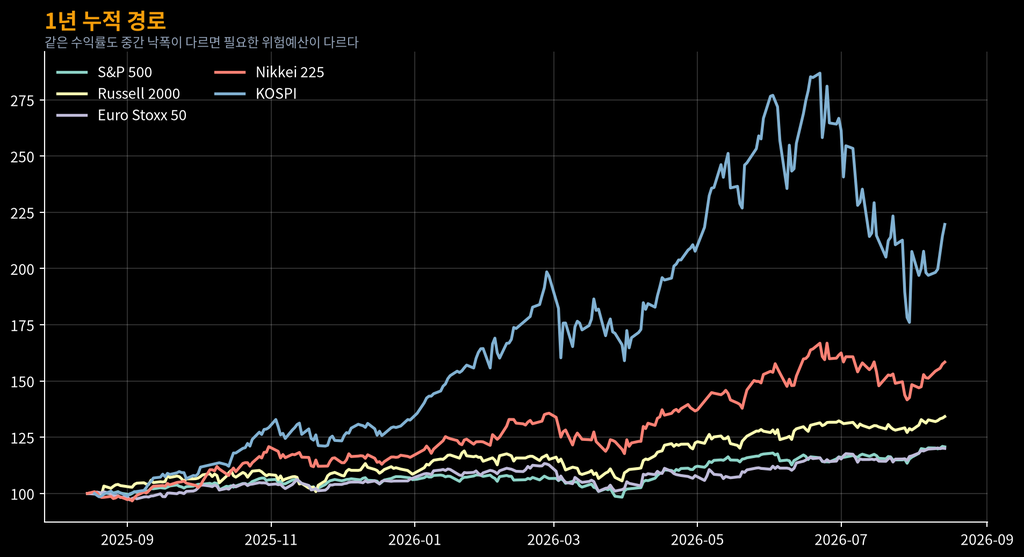

그림 2: 그림 2. 최근 1년 주요 지수의 정규화 경로(시작=100). 종착점뿐 아니라 낙폭과 회복경로를 비교한다.

미국 대형주는 경기둔화가 금리를 낮출 것이라는 기대에 반응했지만, 소매판매 약화는 이익 전망의 하방 위험이기도 하다. 따라서 “나쁜 뉴스=주가 호재”라는 등식은 성장 둔화가 이익 감소로 넘어가는 문턱까지만 유효하다. 유럽·일본·홍콩은 같은 주에 한 방향으로 움직이지 않아 글로벌 유동성이 단일 파동이 아니라 지역별 압력차를 따라 움직였음을 보여준다.

# 3 한국 증시: 급반등의 질

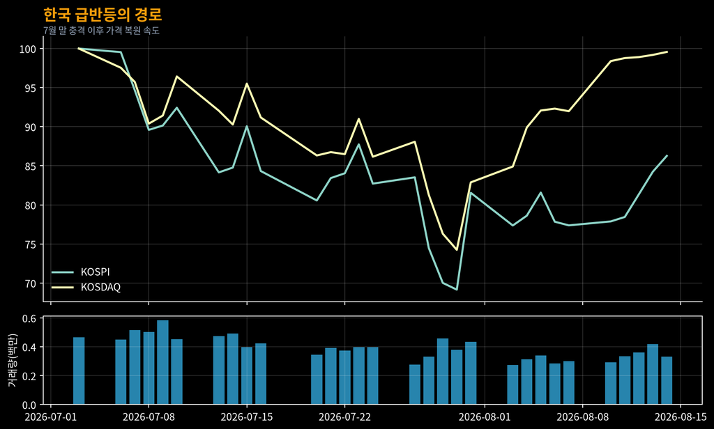

그림 3: 그림 3. 최근 30거래일 KOSPI·KOSDAQ 정규화 경로와 KOSPI 거래량. 반등의 폭과 거래 참여를 함께 본다.

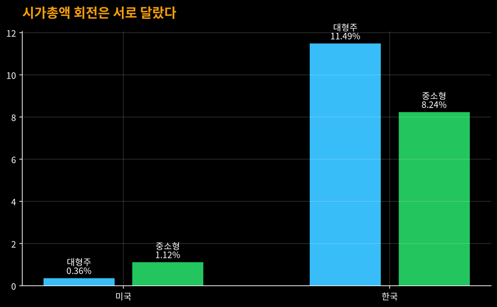

그림 4: 그림 4. 미국·한국의 대형/중소형 대용 지수 주간 성과. 미국은 소형주 우위, 한국은 대형주 우위였다.

한국의 반등은 크지만 일주일 수익률만으로 추세 복귀를 선언하기 어렵다. 급락 직후에는 숏커버, 기계적 리밸런싱, 낙폭과대 매수가 동시에 섞인다. 다음 판정은 지수가 아니라 **상승 종목 확산, 외국인 수급 지속, 20일 변동성 하락**으로 해야 한다.

# 4 섹터 분석과 신호

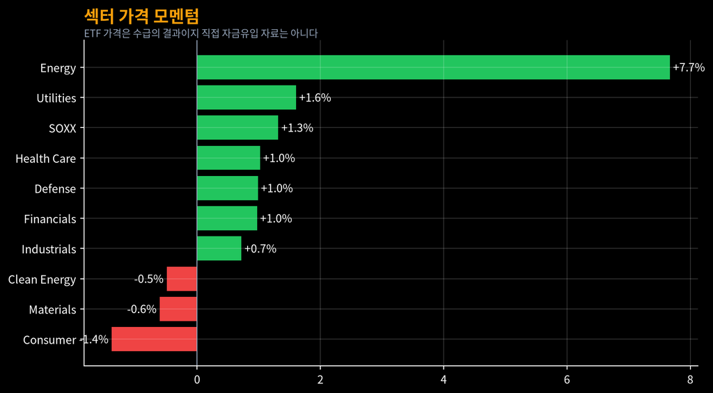

그림 5: 그림 5. 미국 상장 섹터·테마 ETF의 주간 가격 모멘텀. 공식 자금유입액이 아니라 가격 대용치다.

| 섹터 | 판정 | 근거 |
| --- | --- | --- |
| 반도체 | 관망 | SOXX 상대강도는 유지되나 고변동 성장 베타 |
| 금융 | 관망 | 장기금리 상승은 마진에 우호적이나 경기둔화 상쇄 |
| 방산 | 관망 | 구조적 수요와 단기 가격 과열을 분리 |
| 유틸리티 | 방어 | 변동성 완충 기능, 강한 알파 신호는 아님 |
| 청정에너지 | 약세 | 금리·정책 민감도가 높아 추세 확인 필요 |

# 5 NS 자본흐름: 낮은 점도, 다른 유속

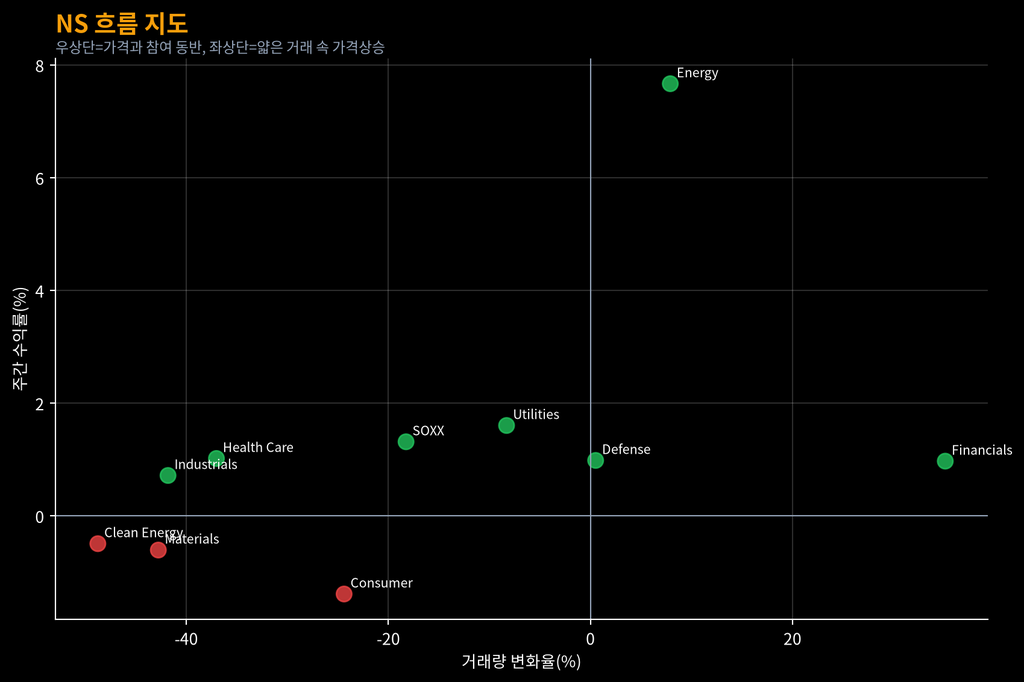

그림 6: 그림 6. 섹터 ETF의 주간 수익률과 거래량 변화율. 화살표가 아닌 관측 가능한 가격·거래량 대용치로 흐름을 표현한다.

VIX 14.25는 점도가 낮아졌음을 뜻하지만, 섹터별 속도와 거래량이 같은 방향은 아니다. 이를 엄밀한 유체역학 레이놀즈 수라고 부를 수는 없다. 여기서 NS는 **변동성=점도, 수익률=유속, 거래량 변화=유량**으로 둔 관찰 프레임이다. 이번 주는 전체 난류보다 국지적 와류—한국 급반등과 소형주 회전—가 더 중요하다.

# 6 TACO와 리스크 대시보드

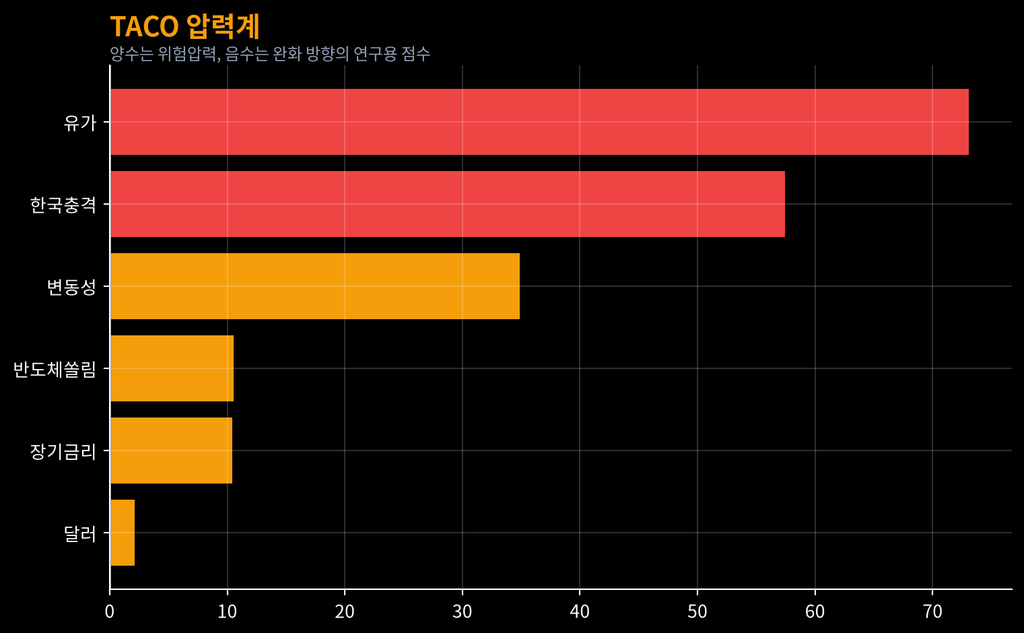

그림 7: 그림 7. TACO 6팩터 연구 점수. 각 시장 대용치의 주간 변화율을 -100~100으로 절단한 상대 위험 신호다.

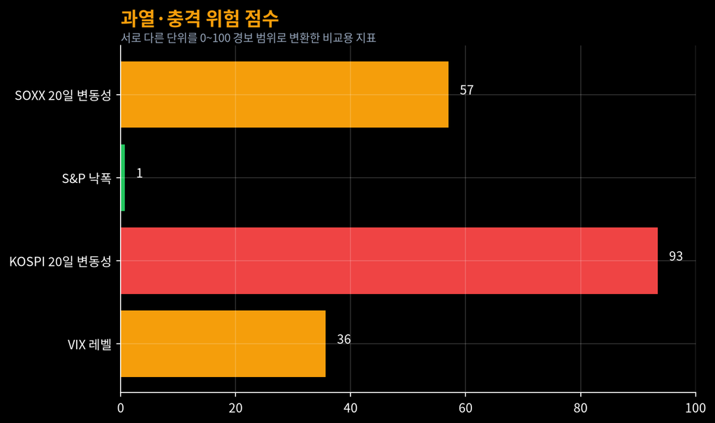

그림 8: 그림 8. 가격에서 계산한 위험 대시보드. 점수가 높을수록 변동성·낙폭 위험이 크다.

# 7 시나리오별 위험예산

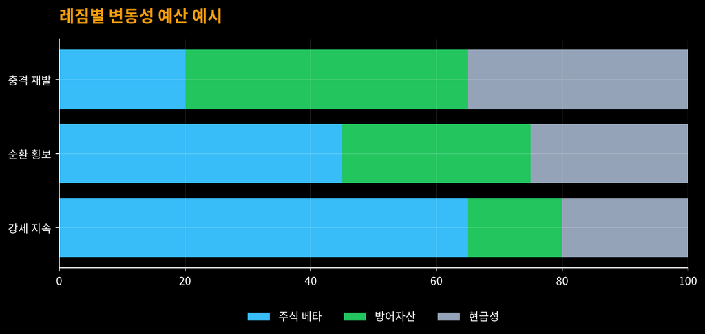

그림 9: 그림 9. 세 레짐에서 위험예산을 어디에 쓰는지 보여주는 연구용 예시. 개인별 포트폴리오 처방이 아니다.

- **강세 지속:** 미국 신고가와 이익 기대가 함께 유지되고 소형주 확산이 이어지는 경우.
- **순환 횡보:** 지수는 버티지만 섹터 주도권이 빠르게 바뀌는 경우. 추세보다 리밸런싱 규칙이 중요하다.
- **충격 재발:** 소매·고용 약화가 금리 호재가 아니라 이익 하향으로 번지는 경우. 현금성 완충이 옵션가치를 갖는다.

# 8 다음 주 확인할 것

1. Russell 2000의 상대강도가 일주일 이상 지속되는가.
2. KOSPI 급반등 뒤 20일 변동성이 실제로 낮아지는가.
3. 낮은 VIX와 약한 실물지표의 괴리가 확대되는가.
4. SOXX 상승이 거래량과 함께 나타나는가.
5. 장기채 약세가 인플레이션 재평가인지 공급·재정 프리미엄인지 구분되는가.

# 9 결론

이번 주 시장은 “위험선호 회복” 한 문장으로 요약되지 않는다. 미국에서는 대형주 신고가 안에서 소형주가 더 강했고, 한국은 충격 뒤 두 자릿수 반등을 보였으며, 장기채는 약했다. **가격은 낙관을 말하지만 경로는 아직 안정성을 증명하지 못했다.** 다음 주의 핵심은 지수 방향이 아니라 상승의 폭, 거래 참여, 변동성 압축이 함께 지속되는지다.

## 9.1 데이터와 재현 범위

- 고정 데이터: `data/market_2025-08-15_2026-08-14.csv`
- 가격 출처: Yahoo Finance chart API, 2026-08-14 종가까지
- 주간 미국 지수 교차검증: [AP 2026-08-14](https://apnews.com/article/wall-street-stocks-dow-nasdaq-41b7cf2acc6562758183b1c5eae73635)
- TACO·NS·위험 점수는 경제적 진실값이 아니라 본문에 공개한 변환식의 산출물이다.